# Titanic Decision GW

I recently watched the Movie Titanic and it got me thinking about a few things. Luckily Kaggle has the Titanic Dataset available online as a competition. I will attempt to create a Decision Tree with the Titanic Dataset and implement some Random Forest Predictions.

We all know Women and Children were first to be saved but I wonder if other Factors went into the percentage of people that lived. I also wanted to see if using Random Forests I can make an accuracte Decision Tree that can predict if someone would live based off features. https://www.kaggle.com/c/titanic/overview

```r
# Import Statments
library(tidyverse)
```

```r
#install.packages("rpart")
library(rpart)
#install.packages("rpart.plot")
library(rpart.plot)
#install.packages("randomForest")
library(randomForest)
# Kaggle's Dataset is great because it splits our testing and training data.
# Our Training Set
train <- read.csv("train.csv")
# Our Testing Set
test <- read.csv("test.csv")
# The actual survived for model comparison
actual <- read.csv("gender_submission.csv")
```

```r
# We want to add / remove any values in the Survived column of test data so that
# The model predicts them.
test$Survived <- NA
```

```r
# Lets take a look at our data.
summary(train)
```

```
##   PassengerId       Survived          Pclass
##  Min.   :  1.0   Min.   :0.0000   Min.   :1.000
##  1st Qu.:223.5   1st Qu.:0.0000   1st Qu.:2.000
##  Median :446.0   Median :0.0000   Median :3.000
##  Mean   :446.0   Mean   :0.3838   Mean   :2.309
##  3rd Qu.:668.5   3rd Qu.:1.0000   3rd Qu.:3.000
##  Max.   :891.0   Max.   :1.0000   Max.   :3.000
##
##                                     Name         Sex           Age
##  Abbing, Mr. Anthony                  :  1   female:314   Min.   : 0.42
##  Abbott, Mr. Rossmore Edward          :  1   male  :577   1st Qu.:20.12
##  Abbott, Mrs. Stanton (Rosa Hunt)     :  1                Median :28.00
##  Abelson, Mr. Samuel                  :  1                Mean   :29.70
##  Abelson, Mrs. Samuel (Hannah Wizosky):  1                3rd Qu.:38.00
##  Adahl, Mr. Mauritz Nils Martin       :  1                Max.   :80.00
##  (Other)                              :885                NA's   :177
##      SibSp           Parch             Ticket         Fare
##  Min.   :0.000   Min.   :0.0000   1601    :  7   Min.   :  0.00
##  1st Qu.:0.000   1st Qu.:0.0000   347082  :  7   1st Qu.:  7.91
##  Median :0.000   Median :0.0000   CA. 2343:  7   Median : 14.45
##  Mean   :0.523   Mean   :0.3816   3101295 :  6   Mean   : 32.20
##  3rd Qu.:1.000   3rd Qu.:0.0000   347088  :  6   3rd Qu.: 31.00
##  Max.   :8.000   Max.   :6.0000   CA 2144 :  6   Max.   :512.33
##                                   (Other) :852
##          Cabin     Embarked
##             :687    :  2
##  B96 B98    :  4   C:168
##  C23 C25 C27:  4   Q: 77
##  G6         :  4   S:644
##  C22 C26    :  3
##  D          :  3
##  (Other)    :186
```

```r
# our col names. This will be used for predicting based off if the data is
# valuable to survival
colnames(train)
```

```
##  [1] "PassengerId" "Survived"    "Pclass"      "Name"        "Sex"
##  [6] "Age"         "SibSp"       "Parch"       "Ticket"      "Fare"
## [11] "Cabin"       "Embarked"
```

```r
# Lets make a table that sees if females actually had a better survival rate
prop.table(table(train$Sex, train$Survived),1)
```

```
##
##                  0         1
##   female 0.2579618 0.7420382
##   male   0.8110919 0.1889081
```

Wow if you were a female you had a 74% chance of surviving and if you were a male you had an 81% chance at death!

```r
# Recursive Partitioning and Regression Trees using the CART decision tree
# algorithm. We are comparing Survived to the Pclass Sex Age Sibsp Parch Fare
# and Embarked on the training dataset. The method is class here because we
# want to look at a survival rate and get a 1 - 0 of likley hood to survive
fitrpart <- rpart(Survived ~ Pclass + Sex + Age + SibSp + Parch + Fare + Embarked,
               data=train,
               method="class")
```

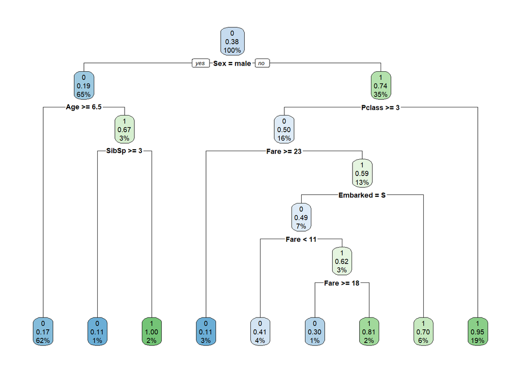

```r
# Using rpart plot we can make a pretty decision tree graph
rpart.plot(fitrpart)
```

The tree shows us some percentages about that data that at first we would not care to look at. For example kids younger that 6.5 had a better chance of survival. The sibsp variable which is ‘# of siblings / spouses aboard the Titanic’ and embarked which is ‘Port of Embarkation’ both had some deciding factors of survival. This is interesting because I normally would not have looked into that at first glance of the data. Pclass Fare Sex and Age all were Commonly known for increasing the rate of survival. Children and women we more likly to live.

```r
# Prediction for kaggle score
Predictionrpart <- predict(fitrpart, test, type = "class")
submitrpart <- data.frame(PassengerId = test$PassengerId, Survived = Predictionrpart, Actual = actual$Survived)
sum(submitrpart$Survived == submitrpart$Actual, na.rm = T) / nrow(submitrpart) *100
```

```
## [1] 91.86603
```

rpart creates a model with 91% accuracy when predicting survival rate.

```r
# The next thing I wanted to try is creating a Randmom forest. The only downside
# with randomForest is NA Values break it hard. So in order to fix the NA values
# we have im using na.action = na.roughfix. This will allow the randomForest
# to run without breaking however if I had more time I would manually combine
# as many feature classes as I could and also get the mean value to replace with
# NA's
# set seed for reproducible results
# ntree agrument will spcify how many trees to grow
# importance will inspect variable importance
# as.factor is needed since we force the model to predict our classification by
# temporarily changing our target variable to a factor
# with only two levels using 0 or 1
set.seed(8675)
fitRF <- randomForest(as.factor(Survived) ~  Pclass + Sex + Age + SibSp + Parch + Fare + Embarked,
                      na.action = na.roughfix,
                      data=train,
                      importance=TRUE,
                      ntree=1500)
# Was getting a weird object reference error when trying to predict
# Stack overflow has this as a solution. Not sure if it will mess with the
# accuracy.

testnew <- rbind(train[1,] , test)
testnew <- testnew[-1,]
# We can now predict
PredictionRF <- predict(fitRF, testnew, type = "class")
PredictionRF
```

```
##    2    3    4    5    6    7    8    9   10   11 <NA>   13   14   15   16   17
##    0    0    0    0    0    0    0    0    1    0 <NA>    0    1    0    1    1
##   18   19   20   21   22   23 <NA>   25   26   27   28   29   30 <NA>   32   33
##    0    0    0    0    1    0 <NA>    0    1    0    1    0    0 <NA>    0    0
##   34 <NA>   36   37 <NA>   39   40 <NA>   42 <NA>   44   45   46   47   48 <NA>
##    0 <NA>    1    0 <NA>    0    0 <NA>    0 <NA>    0    1    1    0    0 <NA>
##   50   51   52   53   54   55 <NA>   57   58   59 <NA>   61   62   63   64   65
##    1    1    0    0    1    1 <NA>    0    0    0 <NA>    1    0    0    0    1
##   66 <NA>   68   69   70   71   72   73   74   75   76   77 <NA>   79   80   81
##    1 <NA>    1    0    0    1    1    0    0    0    1    0 <NA>    1    0    1
##   82   83   84 <NA> <NA> <NA>   88   89 <NA>   91   92 <NA>   94 <NA>   96   97
##    1    0    0 <NA> <NA> <NA>    1    0 <NA>    1    0 <NA>    1 <NA>    0    0
##   98   99  100  101  102  103 <NA>  105  106  107  108 <NA> <NA>  111  112 <NA>
##    1    0    0    0    1    0 <NA>    0    1    0    0 <NA> <NA>    0    0 <NA>
##  114  115  116  117 <NA>  119  120  121  122 <NA>  124  125 <NA>  127  128 <NA>
```

[output cut: 40 more lines]

```r
fitRF
```

```
##
## Call:
##  randomForest(formula = as.factor(Survived) ~ Pclass + Sex + Age +      SibSp + Parch + Fare + Embarked, data = train, importance = TRUE,      ntree = 1500, na.action = na.roughfix)
##                Type of random forest: classification
##                      Number of trees: 1500
## No. of variables tried at each split: 2
##
##         OOB estimate of  error rate: 16.39%
## Confusion matrix:
##     0   1 class.error
## 0 505  44  0.08014572
## 1 102 240  0.29824561
```

```r
# Prediction for kaggle score
submit <- data.frame(PassengerId = testnew$PassengerId, Survived = PredictionRF)
```

```r
# For the purpose of this notebook here is the accuracy of the model
# we create a data frame with the Passenger ID, our predicted Survived rate
# and the actual survival rate of the titanic
# from there we can do a comparison of each row sum and divide the answer by the
# total rows. Multiply by 100 to get a percentage.
t1 <- data.frame(PassengerId = test$PassengerId, Survived = PredictionRF, Actual = actual$Survived)
sum(t1$Survived == t1$Actual, na.rm = T) / nrow(t1) *100
```

```
## [1] 68.89952
```

69% Accuracy using Random Forests. This could be since there are a lot of NA Values appearing in the prediction using the RF Model. Even with the quick fix on the NA’s using na.roughfix. I believe proper Feature Engineering would help the model accuracy. Removing cols that we dont need, combining data, using other decision tree algorithms can all be a factor in imporoving the models accuracy.